# Genre Classification using Spotify Metadata

Author

Tymoteusz Romanowicz

**Display code**

```r
theme_set(
  theme_minimal(base_family = "sans", base_size = 12) +
  theme(
    plot.title = element_text(face = "bold", hjust = 0.5, size = 14),
    plot.subtitle = element_text(hjust = 0.5, color = "gray40"),
    panel.grid.minor = element_blank(),
    legend.position = "bottom"
  )
)
```

# Introduction

Spotify is a Swedish streaming service offering access to over **100 million tracks** and **6 million podcasts**. It has an official API that allows downloading metadata describing the portal’s content and creating applications that communicate with the portal based on it, such as a recommendation system. Variables describing musical tracks that can be extracted using it include the track’s energy, danceability, or tempo, which suggests that they can be used to classify a song into a specific genre. To attempt this, I decided to try building an optimal multi-class classification model that will assign a musical genre to a track based on the extracted metadata.

```
flowchart LR
  A[(Spotify API)] --> B(EDA)
  B --> C{Data Split}
  C -->|Train 80%| D(Recipes / Preprocessing)
  C -->|Test 20%| E(Testing)
  D --> F(Grid Search / Tuning)
  F --> G[Best Model]
  G --> H(Evaluation)
  E --> H
```

# Data Acquisition

## Choosing the Dependent Variable Classes

There is a wide range of musical genres in the world: from *Mongolian throat singing*, through *catstep*, to *pirate metal*. In my project, however, I had to limit myself to just a few fundamental genres that would generalize this diversity well.

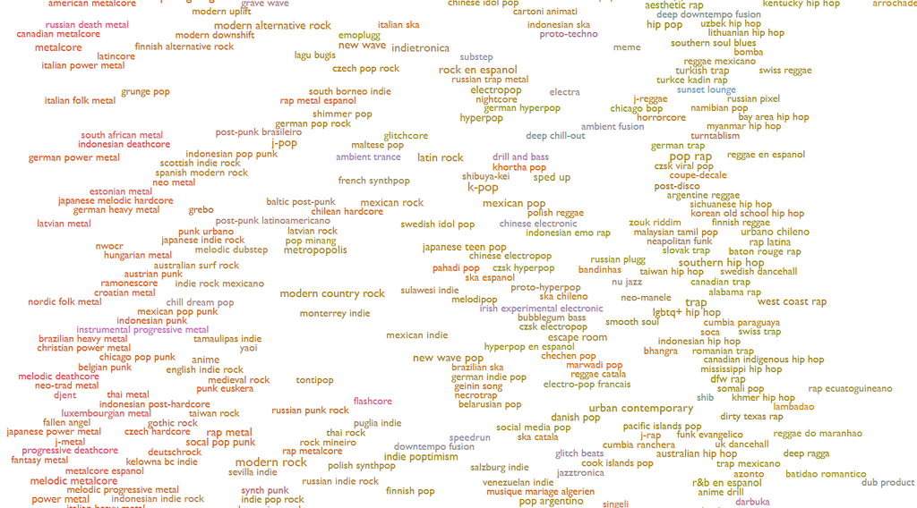

Source: https://everynoise.com/

The **FreeDB** service is a free database that was once used by people burning CDs to pre-fill track information. It describes every song located there using one of the following genres: blues, classical, country, folk, jazz, newage, reggae, rock, soundtrack. I decided that this is a fairly complete list of basic musical genres. However, I took the liberty of replacing *soundtrack* and *newage* with *hip-hop* and *metal*, and then based on it, I defined the states that the dependent variable will take in my model. Ultimately, the list of states that the variable determining the genre can take looks as follows:

- blues,
- classical,
- country,
- folk,
- jazz,
- hip-hop,
- reggae,
- rock,
- metal.

## Creating the Dataset Using the API

The Spotify API allows for the simultaneous downloading of data for all tracks from a selected album, artist profile, or playlist. In order to create a dataset, I searched the service for several playlists containing tracks of a given genre so that there were 200-300 observations per genre and the dataset was as balanced as possible, and then I joined the results into one dataframe.

**Display code**

```r
playlist_names <- c(
  "Blues Classics", "Blues Standards", "Electric Blues Classics", "Classic Blues Guitar",
  "Classical Essentials", "Classical New Releases",
  "Country's Greatest Hits", "Hot Country", "Country Top 50",
  "Fresh Folk", "Roots Rising",
  "jazz classics the best tunes in jazz history",
  "Hip-Hop Drive", "Gold School", "RAP GENERACJA",
  "Reggae Classics", "Summer Sunshine Reggae", "celebrating the film bob marley one love", "Reggae Party",
  "Rock Classics", "All New Rock",
  "Metal Essentials", "00s Metal Classics", "10s Metal Classics"
  )

pb <- txtProgressBar(min = 0,
                     max = length(playlist_names),
                     style = 3,
                     width = 50,
                     char = "=")

dataset <- NULL

for (p in 1:length(playlist_names)) {

  search_results <- search_spotify(
    q = playlist_names[p],
    type = c("playlist"),
    authorization = get_spotify_access_token()
  )

  playlist_id <- search_results %>%
    select(id, name, uri) %>%
    slice_head(n = 1) %>%
    select(id) %>%
    pull()

  p_dt <- get_playlist_audio_features(
    username = "Spotify",
    playlist_uris = c(playlist_id),
  )

  if (p == 1) {
    dataset <- p_dt
  }
  else {
    dataset <- rbind(dataset, p_dt)
  }

  setTxtProgressBar(pb, p)
}

df <- as.data.frame(dataset)
df <- df[,-which(sapply(df, class) == "list")]

# write.csv(df, "spotify-genres-classification.csv")
# write.csv(df, "spotify-genres-classification-new.csv")
```

# Dataset Processing and Cleaning

## Initial Feature Selection

The dataset originally contains many unnecessary variables, such as the identifier of the playlist from which a given track originates or a link to the cover of each song.

| X | playlist_id | playlist_name | playlist_img | playlist_owner_name | playlist_owner_id | danceability | energy | key | loudness | mode | speechiness | acousticness | instrumentalness | liveness | valence | tempo | track.id | analysis_url | time_signature | added_at | is_local | primary_color | added_by.href | added_by.id | added_by.type | added_by.uri | added_by.external_urls.spotify | track.preview_url | track.explicit | … |
| --- | --- | --- | --- | --- | --- | --- | --- | --- | --- | --- | --- | --- | --- | --- | --- | --- | --- | --- | --- | --- | --- | --- | --- | --- | --- | --- | --- | --- | --- | --- |
| 1 | 37i9dQZF1DXd9rSDyQguIk | Blues Classics | https://i.scdn.co/image/ab67706f000000027500902fb0aa21f0bdb12cfd | Spotify | spotify | 0.477 | 0.433 | 11 | -6.473 | 0 | 0.0247 | 0.6890 | 0.000195 | 0.1510 | 0.611 | 82.520 | 1kPBT8S2wJFNAyBMnGVZgL | https://api.spotify.com/v1/audio-analysis/1kPBT8S2wJFNAyBMnGVZgL | 3 | 2020-01-15T21:29:46Z | FALSE | NA | https://api.spotify.com/v1/users/ |  | user | spotify:user: | https://open.spotify.com/user/ | NA | FALSE | … |
| 2 | 37i9dQZF1DXd9rSDyQguIk | Blues Classics | https://i.scdn.co/image/ab67706f000000027500902fb0aa21f0bdb12cfd | Spotify | spotify | 0.427 | 0.626 | 8 | -11.821 | 1 | 0.0385 | 0.0274 | 0.003950 | 0.1060 | 0.743 | 126.877 | 1a2iF9XymafjRk56q7oCxo | https://api.spotify.com/v1/audio-analysis/1a2iF9XymafjRk56q7oCxo | 4 | 2018-03-29T19:44:07Z | FALSE | NA | https://api.spotify.com/v1/users/ |  | user | spotify:user: | https://open.spotify.com/user/ | https://p.scdn.co/mp3-preview/8faa93aa2d3e22a430ee9685e3ad2695c5508417?cid=8e358bf3471a4232babc75cfae3ffffc | FALSE | … |
| 3 | 37i9dQZF1DXd9rSDyQguIk | Blues Classics | https://i.scdn.co/image/ab67706f000000027500902fb0aa21f0bdb12cfd | Spotify | spotify | 0.518 | 0.376 | 9 | -18.248 | 0 | 0.0431 | 0.9330 | 0.860000 | 0.0976 | 0.744 | 158.089 | 4qYHnP5AmKzXbJhciPV8si | https://api.spotify.com/v1/audio-analysis/4qYHnP5AmKzXbJhciPV8si | 4 | 2018-03-29T19:44:07Z | FALSE | NA | https://api.spotify.com/v1/users/ |  | user | spotify:user: | https://open.spotify.com/user/ | NA | FALSE | … |
| 4 | 37i9dQZF1DXd9rSDyQguIk | Blues Classics | https://i.scdn.co/image/ab67706f000000027500902fb0aa21f0bdb12cfd | Spotify | spotify | 0.441 | 0.455 | 10 | -14.207 | 1 | 0.0485 | 0.6200 | 0.001870 | 0.1350 | 0.918 | 160.900 | 2Mr1bGI2E10K7Mt1UJZ6Mw | https://api.spotify.com/v1/audio-analysis/2Mr1bGI2E10K7Mt1UJZ6Mw | 4 | 2018-03-29T19:44:07Z | FALSE | NA | https://api.spotify.com/v1/users/ |  | user | spotify:user: | https://open.spotify.com/user/ | NA | FALSE | … |
| 5 | 37i9dQZF1DXd9rSDyQguIk | Blues Classics | https://i.scdn.co/image/ab67706f000000027500902fb0aa21f0bdb12cfd | Spotify | spotify | 0.598 | 0.735 | 2 | -10.882 | 1 | 0.0973 | 0.4400 | 0.000215 | 0.6810 | 0.615 | 111.129 | 58PSYdY0GFg0LFb2PxYk4T | https://api.spotify.com/v1/audio-analysis/58PSYdY0GFg0LFb2PxYk4T | 3 | 2018-03-29T19:44:07Z | FALSE | NA | https://api.spotify.com/v1/users/ |  | user | spotify:user: | https://open.spotify.com/user/ | https://p.scdn.co/mp3-preview/4cfb55a2ddbd24a5538f21588a85fa5727025aa7?cid=8e358bf3471a4232babc75cfae3ffffc | FALSE | … |
| 6 | 37i9dQZF1DXd9rSDyQguIk | Blues Classics | https://i.scdn.co/image/ab67706f000000027500902fb0aa21f0bdb12cfd | Spotify | spotify | 0.676 | 0.334 | 5 | -10.572 | 1 | 0.0508 | 0.8620 | 0.000000 | 0.3200 | 0.867 | 158.000 | 4KMXlzvtC8xjLseDqDjpeU | https://api.spotify.com/v1/audio-analysis/4KMXlzvtC8xjLseDqDjpeU | 4 | 2020-01-15T21:29:46Z | FALSE | NA | https://api.spotify.com/v1/users/ |  | user | spotify:user: | https://open.spotify.com/user/ | NA | FALSE | … |

They should be disposed of immediately to increase the transparency of the dataset and facilitate further analysis.

The feature set after initial selection thus looked as follows:

Feature set description

[output not shown]

**Note**

I intentionally kept the `track_name` variable acting as an identifier to facilitate working with the dataset and interpreting the results.

Looking at the above feature set, one can immediately notice that the `mode_name` variable is redundant with respect to the `mode` variable, `key_name` is redundant with respect to `key`, and `key_mode` being a combination of the previous variables is also superfluous, so I am getting rid of them right away.

**Display code**

```r
df <- df %>%
  select(-c(key_mode, key_name, mode_name))
```

## Creating the Dependent Variable Determining the Track Genre

The variable determining the genre was not part of the feature set extracted directly from the API, so I have to create it myself using the variable determining the name of the playlist from which the track originates.

| Variable | Frequency |
| --- | --- |
| 00s Metal Classics | 100 |
| 10s Metal Classics | 75 |
| All New Rock | 50 |
| Blues Classics | 70 |
| Blues Standards | 58 |
| Classic Blues Guitar | 50 |
| Classical Essentials | 159 |
| Classical New Releases | 68 |
| Country's Greatest Hits | 100 |
| Country Top 50 | 50 |
| Electric Blues Classics | 60 |
| Fresh Folk | 150 |
| Gold School | 50 |
| Hip-Hop Drive | 150 |
| Hot Country | 50 |
| Jazz Classics | 250 |
| Metal Essentials | 100 |
| RAP GENERACJA | 50 |
| REGGAE | 128 |
| Reggae Classics | 100 |
| Reggae Party | 81 |
| Rock Classics | 200 |
| Roots Rising | 100 |
| Summer Sunshine Reggae | 65 |

**Display code**

```r
df$genre <- "NA"

metal_playlists <- c("00s Metal Classics", "10s Metal Classics", "Metal Essentials")
hiphop_playlists <- c("Hip-Hop Drive", "Gold School", "RAP GENERACJA")
rock_playlists <- c("All New Rock", "Rock Classics")
blues_playlists <- c("Blues Classics", "Blues Standards", "Classic Blues Guitar", "Electric Blues Classics")
classical_playlists <- c("Classical Essentials", "Classical New Releases")
country_playlists <- c("Country's Greatest Hits", "Country Top 50", "Hot Country")
folk_playlists <- c("Fresh Folk", "Roots Rising")
jazz_playlists <- c("Jazz Classics")
reggae_playlists <- c("Reggae Classics", "Summer Sunshine Reggae", "Reggae Party")

df[df$playlist_name %in% metal_playlists,]$genre <- "metal"
df[df$playlist_name %in% hiphop_playlists,]$genre <- "hiphop"
df[df$playlist_name %in% rock_playlists,]$genre <- "rock"
df[df$playlist_name %in% blues_playlists,]$genre <- "blues"
df[df$playlist_name %in% classical_playlists,]$genre <- "classical"
df[df$playlist_name %in% country_playlists,]$genre <- "country"
df[df$playlist_name %in% folk_playlists,]$genre <- "folk"
df[df$playlist_name %in% jazz_playlists,]$genre <- "jazz"
df[df$playlist_name %in% reggae_playlists,]$genre <- "reggae"

df <- df %>%
  filter(genre != "NA")
```

The number of tracks belonging to individual genres presents itself as follows. It can be seen that, as intended, each genre has 200-300 observations, thanks to which the dataset is fairly balanced.

| Variable | Frequency |
| --- | --- |
| blues | 238 |
| classical | 227 |
| country | 200 |
| folk | 250 |
| hiphop | 250 |
| jazz | 250 |
| metal | 275 |
| reggae | 246 |
| rock | 250 |

The `genre` variable determining the genre has already been created, so I can get rid of the `playlist_name` feature.

**Display code**

```r
df <- df %>%
  select(-playlist_name)
```

## Checking for Missing Values

**Display code**

```r
any(is.na(df))
```

```
[1] TRUE
```

|  | danceability | energy | key | loudness | mode | speechiness | acousticness | instrumentalness | liveness | valence | tempo | time_signature | track.explicit | track.duration_ms | track.name | track.popularity | track.album.release_date | genre |
| --- | --- | --- | --- | --- | --- | --- | --- | --- | --- | --- | --- | --- | --- | --- | --- | --- | --- | --- |
| 402 | NA | NA | NA | NA | NA | NA | NA | NA | NA | NA | NA | NA | NA | NA | NA | NA | NA | classical |

It looks like the dataset has missing values. After displaying them, however, it turns out that they constitute a single row in which the values of every variable except `genre` are NA. This is probably due to the API downloading a track from a classical music playlist that is no longer available on the service. Given that this is the only row with missing values in the entire dataset, it can safely be disposed of without the need for data imputation.

**Display code**

```r
df <- na.omit(df)
any(is.na(df))
```

```
[1] FALSE
```

## Checking for Duplicates

Observations from individual genres are mostly made up of tracks from several different playlists. However, it is not excluded that in a few playlists for a single genre, a certain song was repeated. It should therefore be investigated whether such a situation occurred and we are dealing with duplicates.

| Is duplicated | Frequency |
| --- | --- |
| FALSE | 2023 |
| TRUE | 162 |

It turns out that as many as 162 tracks were repeated in our dataset. Their repetitions should be removed to eliminate the problem of identical observations.

**Display code**

```r
df <- df %>%
  distinct(track.name, .keep_all = TRUE)
```

After leaving rows with unique titles in the dataset, the problem is resolved.

| Is duplicated | Frequency |
| --- | --- |
| FALSE | 2023 |

## Data Validity Verification

| variable | class | examples |
| --- | --- | --- |
| danceability | numeric | 0.477, 0.427, 0.518, 0.441, ... |
| energy | numeric | 0.433, 0.626, 0.376, 0.455, ... |
| key | integer | 11, 8, 9, 10, ... |
| loudness | numeric | -6.473, -11.821, -18.248, -14.207, ... |
| mode | integer | 0, 1, 0, 1, ... |
| speechiness | numeric | 0.0247, 0.0385, 0.0431, 0.0485, ... |
| acousticness | numeric | 0.689, 0.0274, 0.933, 0.62, ... |
| instrumentalness | numeric | 0.000195, 0.00395, 0.86, 0.00187, ... |
| liveness | numeric | 0.151, 0.106, 0.0976, 0.135, ... |
| valence | numeric | 0.611, 0.743, 0.744, 0.918, ... |
| tempo | numeric | 82.52, 126.877, 158.089, 160.9, ... |
| time_signature | integer | 3, 4, 4, 4, ... |
| track.explicit | logical | "FALSE", "FALSE", "FALSE", "FALSE", ... |
| track.duration_ms | integer | 156653, 219586, 233560, 152350, ... |
| track.name | character | "I'd Rather Go Blind", "Pride and Joy", ... |
| track.popularity | integer | 77, 67, 65, 62, ... |
| track.album.release_date | character | "1968-04-18", "1983", "1974-01-01", "1962-01-01", ... |
| genre | character | "blues", "blues", "blues", "blues", ... |

Displaying the type and sample observations for each variable immediately allows us to notice a few problems with the dataset that will have to be addressed. These include, among others, incorrect data types or the fact that the variable representing the date on which the track was published is sometimes expressed with accuracy to the day, and sometimes to the release year.

| statistic | min | median | mean | max | sd |
| --- | --- | --- | --- | --- | --- |
| danceability | 0.0000000 | 0.5520000 | 0.5421811 | 0.9750000 | 0.1858526 |
| energy | 0.0021200 | 0.5820000 | 0.5495664 | 0.9980000 | 0.2891074 |
| loudness | -43.738000 | -8.320000 | -10.197988 | -1.299000 | 6.514778 |
| speechiness | 0.00000000 | 0.04630000 | 0.08191068 | 0.60200000 | 0.08278790 |
| acousticness | 0.00000232 | 0.25000000 | 0.38580650 | 0.99600000 | 0.36847665 |
| instrumentalness | 0.0000000 | 0.0004180 | 0.1550245 | 0.9580000 | 0.2981258 |
| liveness | 0.0243000 | 0.1220000 | 0.1740335 | 0.9790000 | 0.1368237 |
| valence | 0.0000000 | 0.4910000 | 0.4870162 | 0.9700000 | 0.2618542 |
| tempo | 0.00000 | 115.48600 | 117.53169 | 208.57600 | 31.57082 |
| track.duration_ms | 77032.0 | 230466.0 | 257778.4 | 1637893.0 | 117245.8 |
| track.popularity | 0.00000 | 49.00000 | 45.40929 | 93.00000 | 24.02641 |

Descriptive statistics for continuous variables also illustrate several anomalies in our dataset. It can be seen, for example, that there is a track with a tempo equal to 0, which is impossible. There are also observations with zero popularity, which is highly unlikely considering that practically every playlist from which data was downloaded contained genre classics.

### Removing the Row with Zero Tempo

**Display code**

```r
df[df$tempo < 40, ] %>% kable("html") %>% kable_styling("striped")
```

|  | danceability | energy | key | loudness | mode | speechiness | acousticness | instrumentalness | liveness | valence | tempo | time_signature | track.explicit | track.duration_ms | track.name | track.popularity | track.album.release_date | genre |
| --- | --- | --- | --- | --- | --- | --- | --- | --- | --- | --- | --- | --- | --- | --- | --- | --- | --- | --- |
| 268 | 0 | 0.0842 | 9 | -19.397 | 1 | 0 | 0.755 | 0.889 | 0.262 | 0 | 0 | 0 | FALSE | 432533 | Serenade for Strings in E Major, Op. 22, B. 52: II. Tempo di valse | 65 | 1991-01-01 | classical |

After displaying all rows that have a tempo below 40 bpm, it turns out that there is only one such track. It can therefore be removed without fear that it will cause a huge difference in the dataset.

**Display code**

```r
df <- df %>%
  filter(tempo != 0)
```

### Abandoning the `popularity` Variable

**Display code**

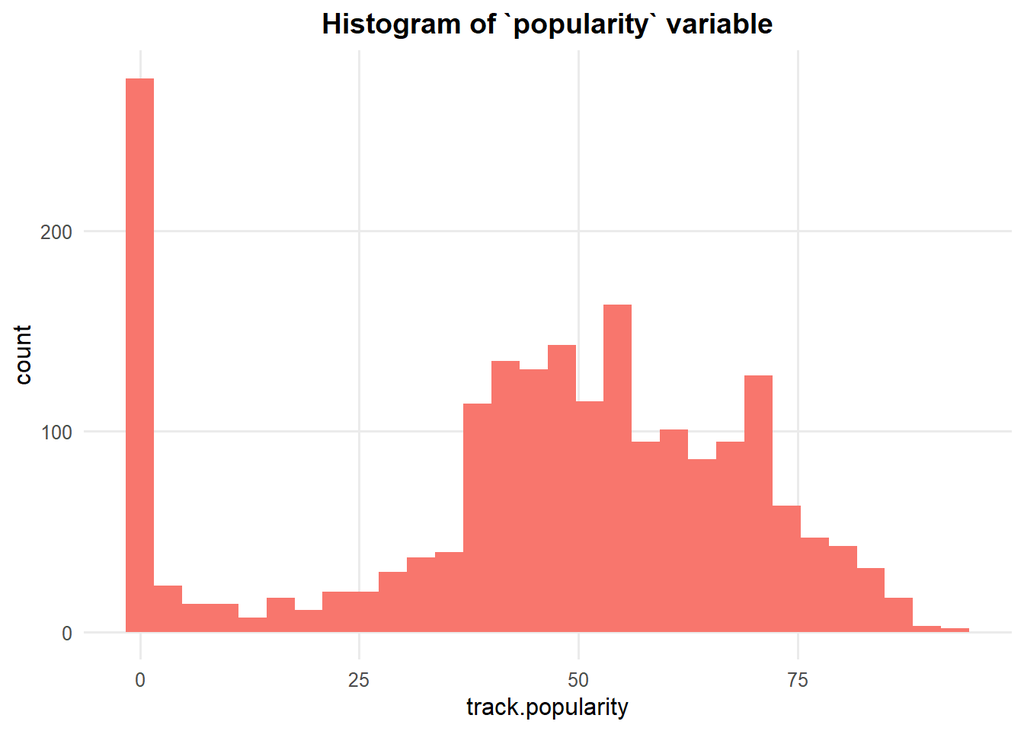

```r
ggplot(df, aes(x = track.popularity)) + geom_histogram(bins = 30, fill = "#F8766D") + labs(title = "Histogram of `popularity` variable")
```

Displaying the histogram of the `popularity` variable allows one to notice that we have a lot of variables with popularity equal or close to 0. Let’s check how many rows have “zero” popularity.

**Display code**

```r
nrow(df[df$track.popularity == 0, ])
```

```
[1] 245
```

**Display code**

```r
tail(df[df$track.popularity == 0, ]$track.name, 10)
```

```
 [1] "Repentless"
 [2] "Storytime"
 [3] "Faster"
 [4] "Unbreakable"
 [5] "To Hell And Back"
 [6] "Reign Of Darkness"
 [7] "The Dirt (Est. 1981) [feat. Machine Gun Kelly]"
 [8] "Koolaid"
 [9] "Looking Down The Barrel Of Today"
[10] "My Own Grave"
```

We have as many as 245 such rows. It can therefore be concluded that this variable is not defined by the Spotify service in a correct way and contains improbable values, which is confirmed by the fact that Slayer’s track “Repentless” also has “zero” popularity. This prompted me to eliminate it from the dataset.

**Display code**

```r
df <- df %>%
  select(-track.popularity)
```

### Changing Values in the `time_signature` Column

| Value | Frequency |
| --- | --- |
| 1 | 18 |
| 3 | 209 |
| 4 | 1771 |
| 5 | 24 |

After displaying the number of tracks in particular meters, it turns out that the dataset is dominated by tracks in the most popular meter, which is 4/4. However, it is suspicious that we have 18 tracks in a 1/4 meter, which is most likely an error. Let’s look at the tracks in this meter to identify the source of such coding.

**Display code**

```r
tail(df[df$time_signature == 1, ]$track.name)
```

```
[1] "Die tote Stadt, Op. 12: Mein Sehnen, mein Wähnen (Pierrot's Tanzlied)"
[2] "Hard To Tell"
[3] "Wanna Get To Know You"
[4] "Solsbury Hill"
[5] "Money - 2011 Remastered Version"
[6] "Pneuma"
```

It turns out that this meter is assigned either to tracks that have a “fluid” structure, characteristic of classical music, or those that are characterized by an unstable meter, meaning one that frequently changes during the course of the track. A good example is the track “Money” by the band Pink Floyd (the main motif is in 7/4, but then during the “bridge” it transitions to 4/4, and then 6/4, to later return to 7/4 again), or the track “Pneuma” by the band Tool, where the meter changes practically all the time (it even has a repeating segment in which we are dealing with consecutive measures in the meters 33/16, 33/16, 28/16, and 30/16!).

[video not shown]

So it is no wonder that the API, when extracting the meter from these songs, “went crazy” and classified them as 1/4, which would roughly mean that there is one beat per entire measure, which is of course untrue in this case. Given that tracks in 3/4 and 5/4 meters, as well as “tracks in 1/4 meter”, occur relatively rarely, I decided to merge them into one “other” category, while leaving tracks in 4/4 meter unchanged.

**Display code**

```r
df$time_signature <- as.character(df$time_signature)
df$time_signature <- ifelse(df$time_signature == "4",
                            df$time_signature,
                            "other")
```

This is how the division of tracks due to the presence of a 4/4 meter or another presents itself now.

| Value | Frequency |
| --- | --- |
| 4 | 1771 |
| other | 251 |

### Changing the `track.album.release_date` Variable to the `decade` Variable

From previous deductions, it resulted that the variable representing the release date of the track is expressed with varying accuracy, because sometimes we have the full date given in it, and sometimes only the year. In order to unify the accuracy of the value of this feature, I decided to extract only the year from each date. Then I decided that it would be a good idea to assign each year to a particular decade in order to categorize the variable. There were few songs from the 30s, 40s, 50s, and 60s, so I grouped them into one “other” category (or `<70`), to make the groups more balanced.

**Display code**

```r
df$track.album.release_date <- substr(df$track.album.release_date, 1, 4)
colnames(df)[16] <- "release_year"
df$release_year <- as.integer(df$release_year)
df$decade <- (df$release_year - df$release_year %% 10) %% 100
df[df$decade %in% c(30, 40, 50, 60), ]$decade <- "<70"
df[df$decade == 0, ]$decade <- "00"
df$decade <- as.character(df$decade)
df$decade <- factor(df$decade, levels = c("<70", "70", "80", "90", "00", "10", "20"))

df <- df %>%
  select(-release_year)
```

In this way, I created the categorical variable `decade`, which takes the following values with a given frequency:

| Value | Frequency |
| --- | --- |
| <70 | 233 |
| 70 | 140 |
| 80 | 126 |
| 90 | 227 |
| 00 | 447 |
| 10 | 265 |
| 20 | 584 |

### Changing Values in the `track.explicit` Column to 0 and 1

The `track.explicit` variable takes boolean values TRUE or FALSE, so I decide to change them to values 1 and 0, where 1 corresponds to a track that contains explicit content.

**Display code**

```r
df$track.explicit <- ifelse(df$track.explicit == TRUE, 1, 0)
```

The distribution of this feature presents itself as follows:

| Value | Frequency |
| --- | --- |
| 0 | 1714 |
| 1 | 308 |

### Coding Categorical Variables

Variables that take a limited number of values were appropriately coded as categorical variables.

**Display code**

```r
df$genre <- factor(df$genre)
df$key <- factor(df$key)
df$mode <- factor(df$mode)
df$time_signature <- factor(df$time_signature)
df$track.explicit <- factor(df$track.explicit)
```

### Changing the Unit in the `track.duration_ms` Variable to Seconds

The `track.duration_ms` variable is expressed in milliseconds, thus taking very large values. To facilitate the interpretation of this feature, I will change the unit to seconds by dividing its values by 1000.

**Display code**

```r
df$track.duration_s <- df$track.duration_ms / 1000
df <- df %>%
  select(-track.duration_ms)
```

## Effect of Dataset Processing and Cleaning

| variable | class | examples |
| --- | --- | --- |
| danceability | numeric | 0.477, 0.427, 0.518, 0.441, ... |
| energy | numeric | 0.433, 0.626, 0.376, 0.455, ... |
| key | Factor w/ 12 levels | "11", "8", "9", "10", ... |
| loudness | numeric | -6.473, -11.821, -18.248, -14.207, ... |
| mode | Factor w/ 2 levels | "0", "1", "0", "1", ... |
| speechiness | numeric | 0.0247, 0.0385, 0.0431, 0.0485, ... |
| acousticness | numeric | 0.689, 0.0274, 0.933, 0.62, ... |
| instrumentalness | numeric | 0.000195, 0.00395, 0.86, 0.00187, ... |
| liveness | numeric | 0.151, 0.106, 0.0976, 0.135, ... |
| valence | numeric | 0.611, 0.743, 0.744, 0.918, ... |
| tempo | numeric | 82.52, 126.877, 158.089, 160.9, ... |
| time_signature | Factor w/ 2 levels | "other", "4", "4", "4", ... |
| track.explicit | Factor w/ 2 levels | "0", "0", "0", "0", ... |
| track.name | character | "I'd Rather Go Blind", "Pride and Joy", ... |
| genre | Factor w/ 9 levels | "blues", "blues", "blues", "blues", ... |
| decade | Factor w/ 7 levels | "<70", "80", "70", "<70", ... |
| track.duration_s | numeric | 156.653, 219.586, 233.56, 152.35, ... |

It can be seen that all variables now have correctly encoded types.

| statistic | min | median | mean | max | sd |
| --- | --- | --- | --- | --- | --- |
| danceability | 0.0623000 | 0.5520000 | 0.5424492 | 0.9750000 | 0.1855068 |
| energy | 0.0021200 | 0.5820000 | 0.5497965 | 0.9980000 | 0.2889935 |
| loudness | -43.738000 | -8.318500 | -10.193438 | -1.299000 | 6.513174 |
| speechiness | 0.02280000 | 0.04635000 | 0.08195119 | 0.60200000 | 0.08278832 |
| acousticness | 0.00000232 | 0.24900000 | 0.38562391 | 0.99600000 | 0.36847625 |
| instrumentalness | 0.0000000 | 0.0004145 | 0.1546615 | 0.9580000 | 0.2977521 |
| liveness | 0.0243000 | 0.1215000 | 0.1739900 | 0.9790000 | 0.1368435 |
| valence | 0.0280000 | 0.4910000 | 0.4872571 | 0.9700000 | 0.2616948 |
| tempo | 48.71800 | 115.48850 | 117.58982 | 208.57600 | 31.47017 |
| track.duration_s | 77.0320 | 230.4130 | 257.6919 | 1637.8930 | 117.2103 |

Descriptive statistics also show no irregularities in the dataset.

# Visualizing Relationships Between Variables

## Distributions of Variables

**Categorical Variables**

**Genre**

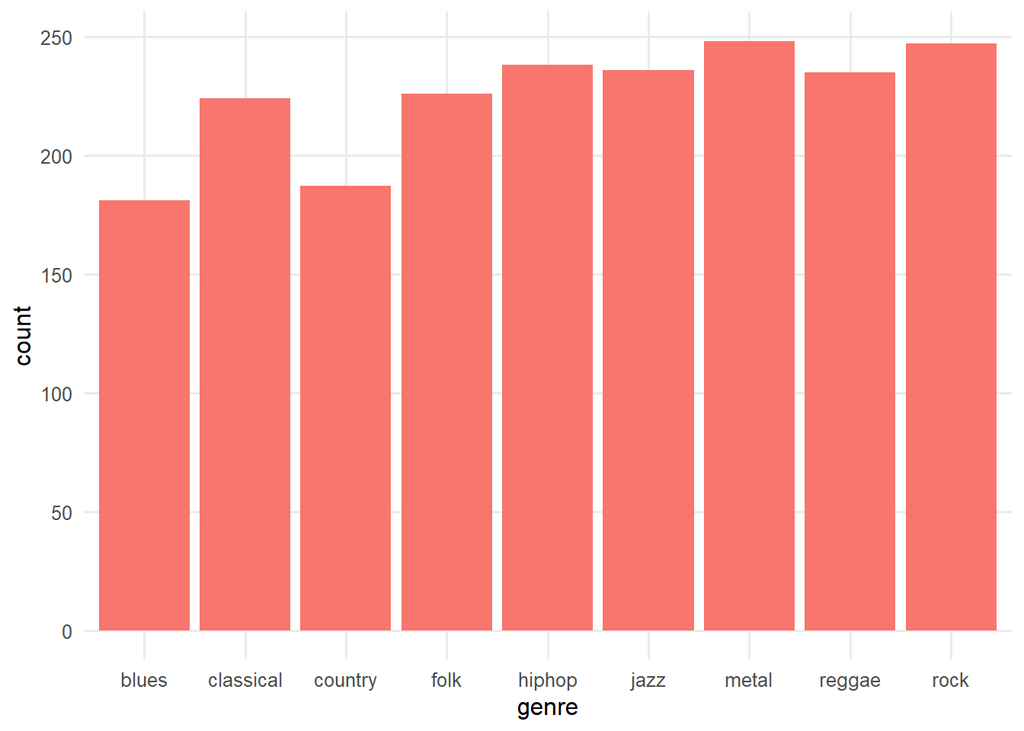

**Keys**

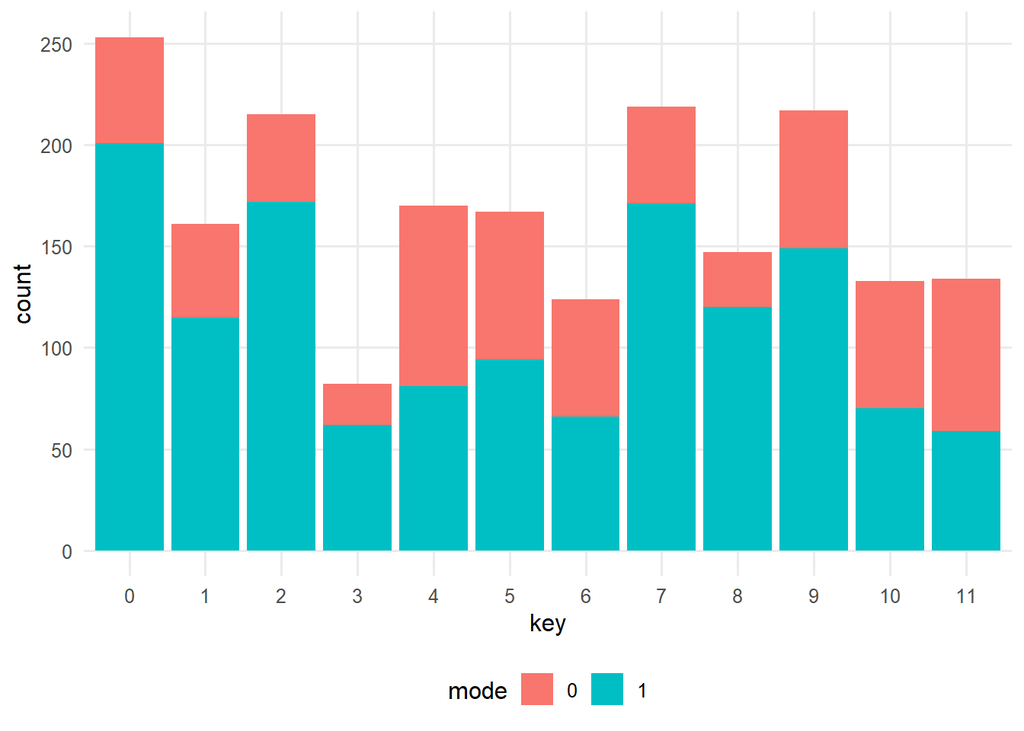

**Meter**

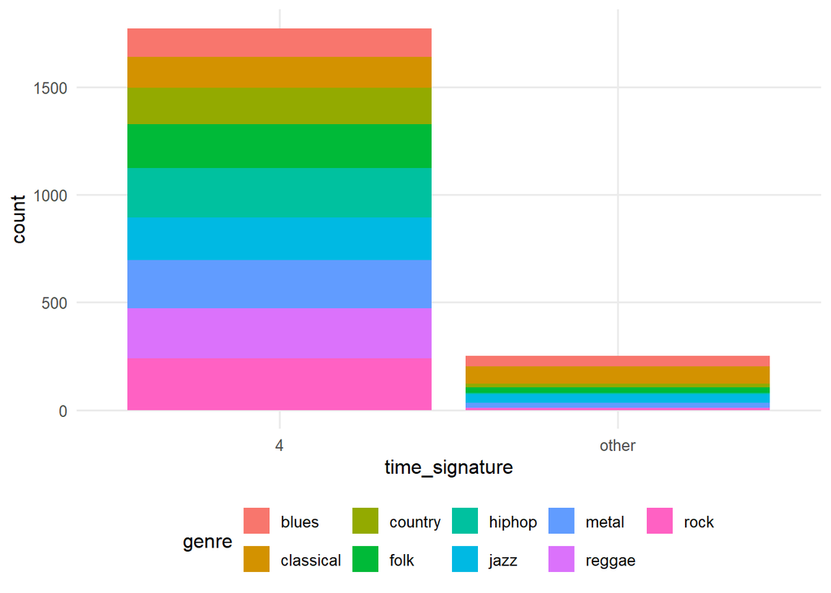

**Explicitness**

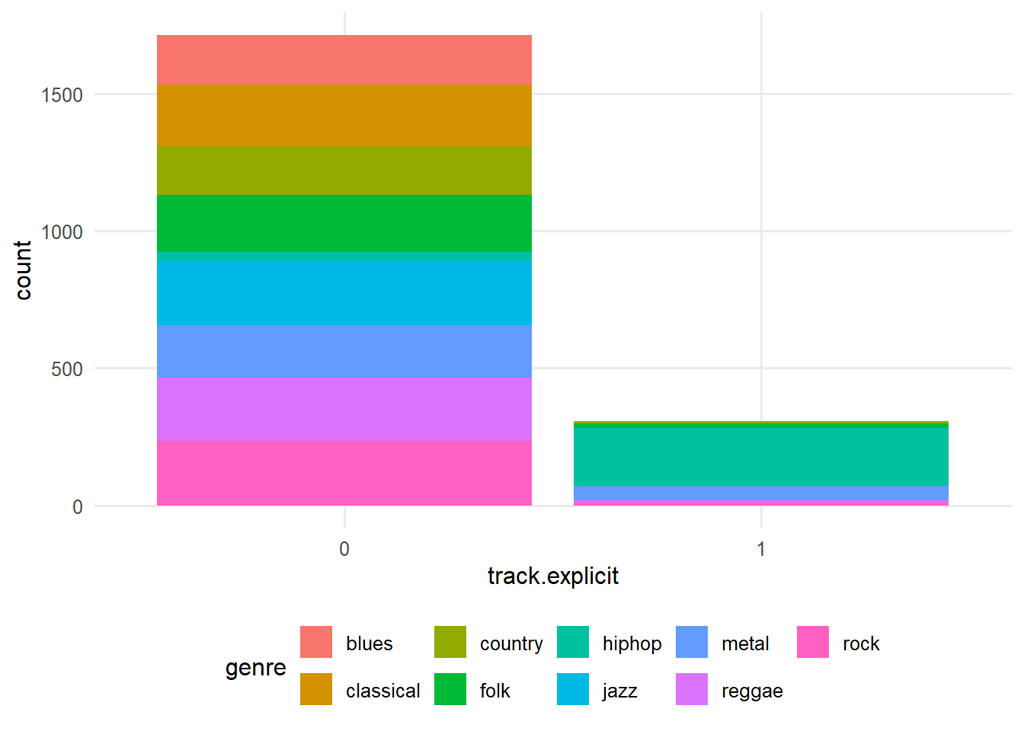

**Decade**

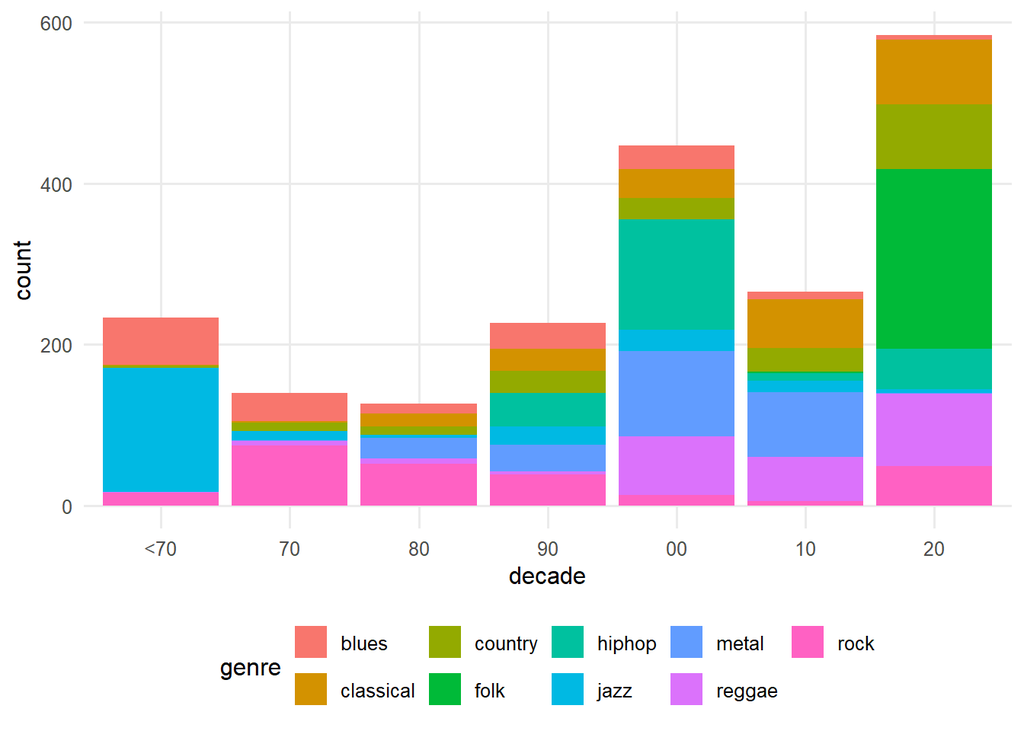

**Continuous Variables**

**Danceability**

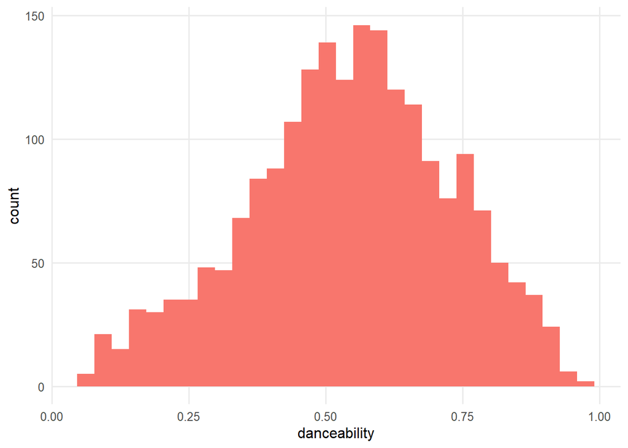

**Energy**

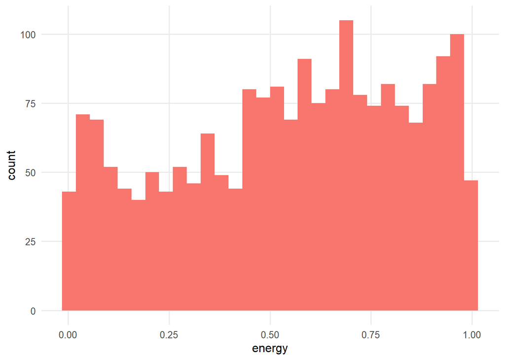

**Loudness**

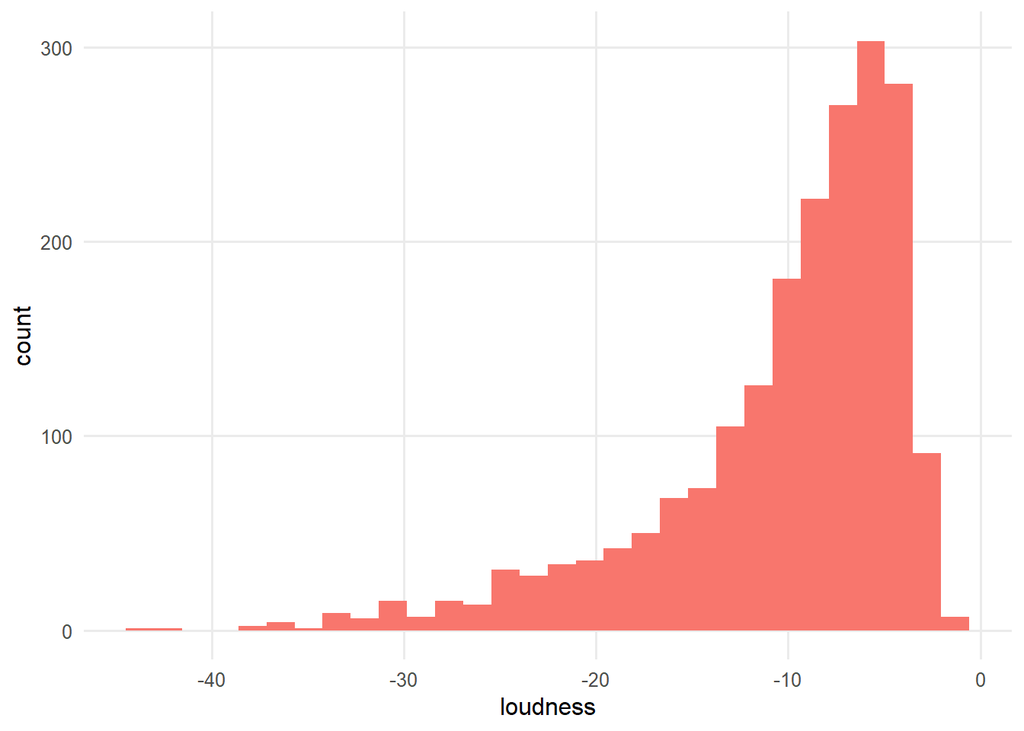

**Speechiness**

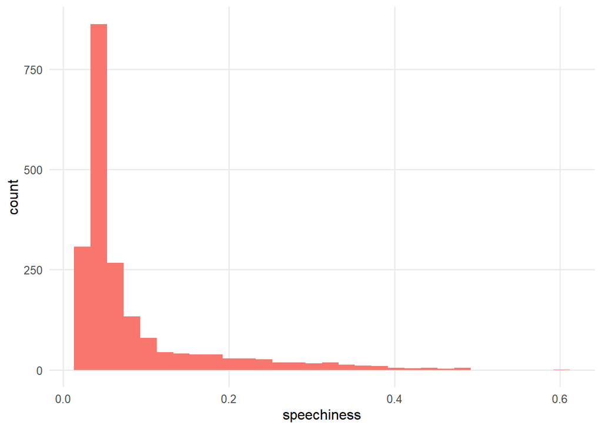

**Acousticness**

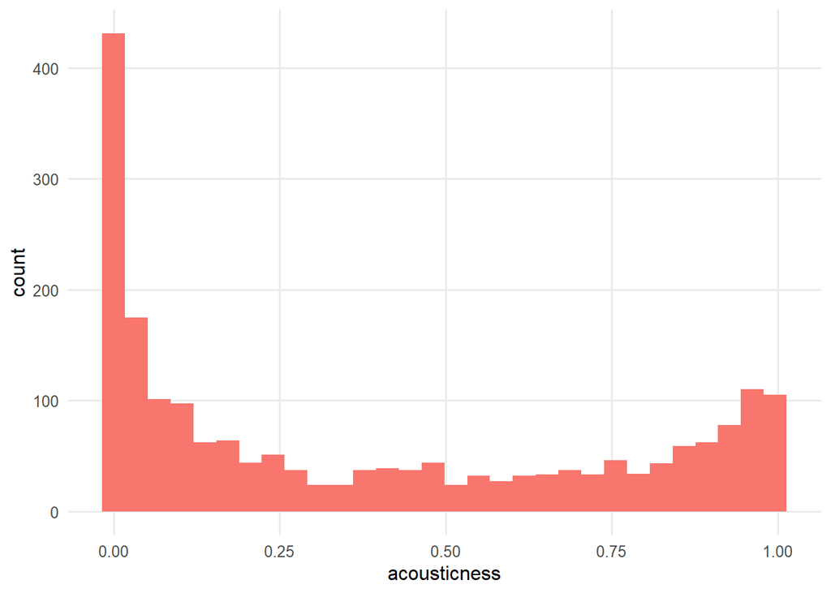

**Instrumentalness**

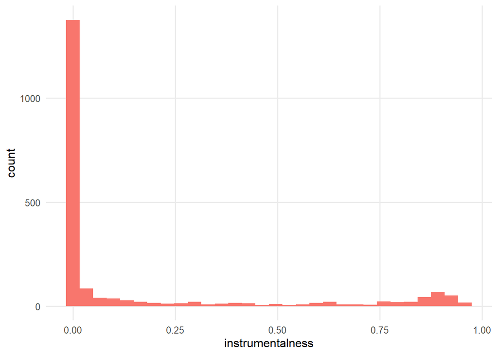

**Liveness**

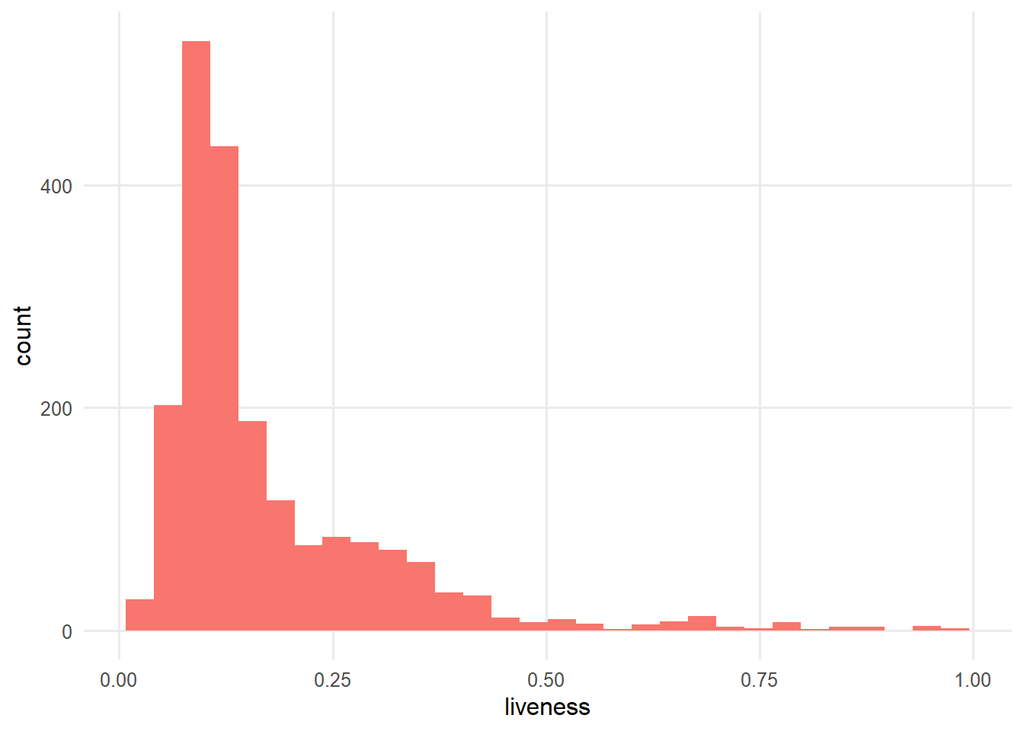

**Valence**

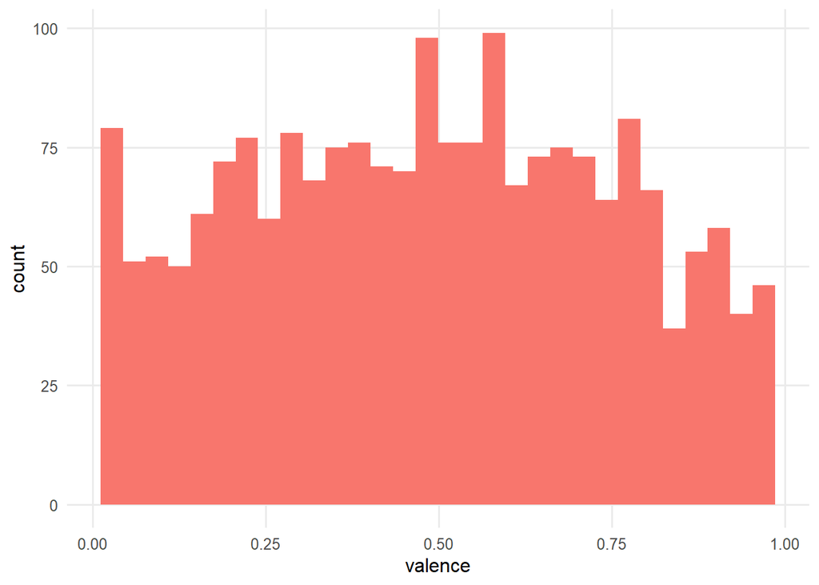

**Tempo**

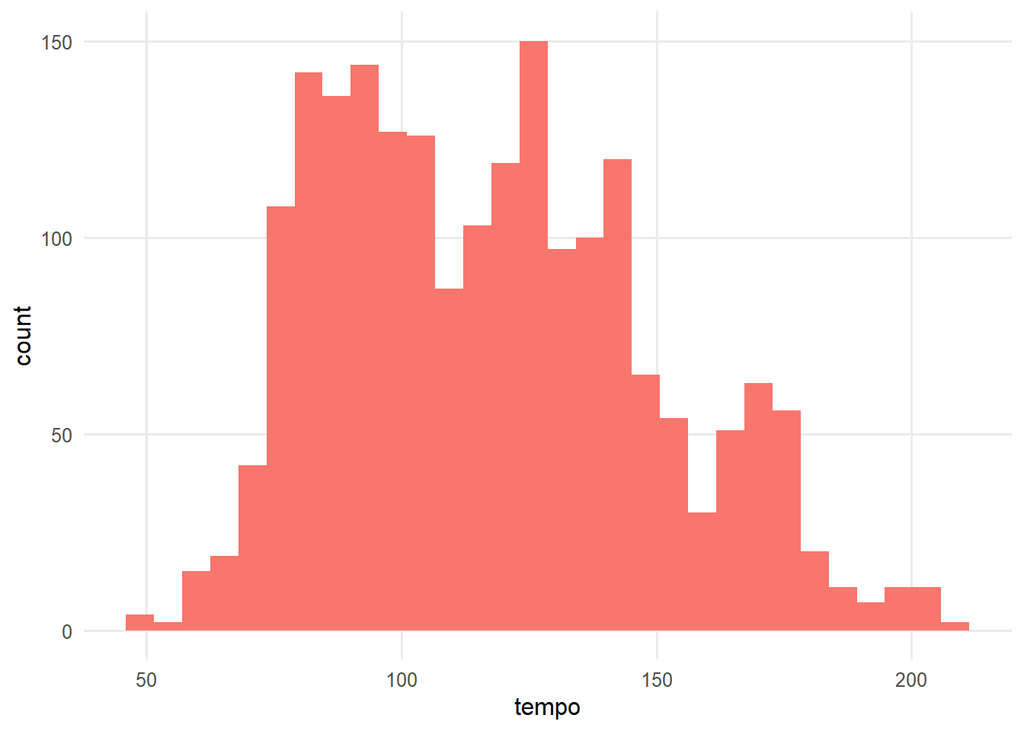

**Duration**

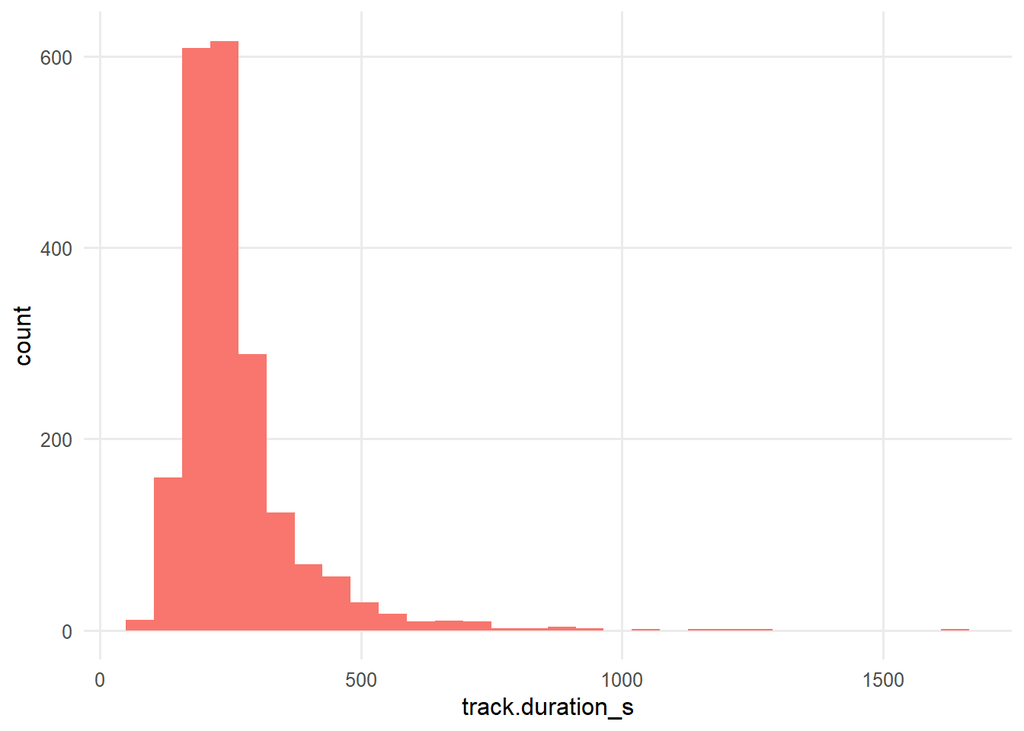

**Important**

It is clearly visible that some continuous variables have heavy-tailed asymmetrical distributions. This means that some machine learning models will require prior transformation of these variables to force greater symmetry of the distributions.

### Decade Distributions Depending on Genre

**Blues**

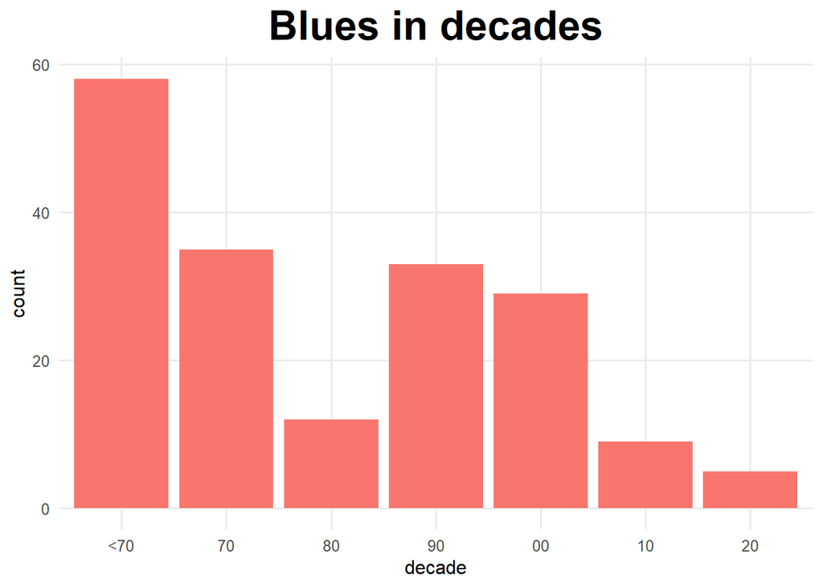

**Classical**

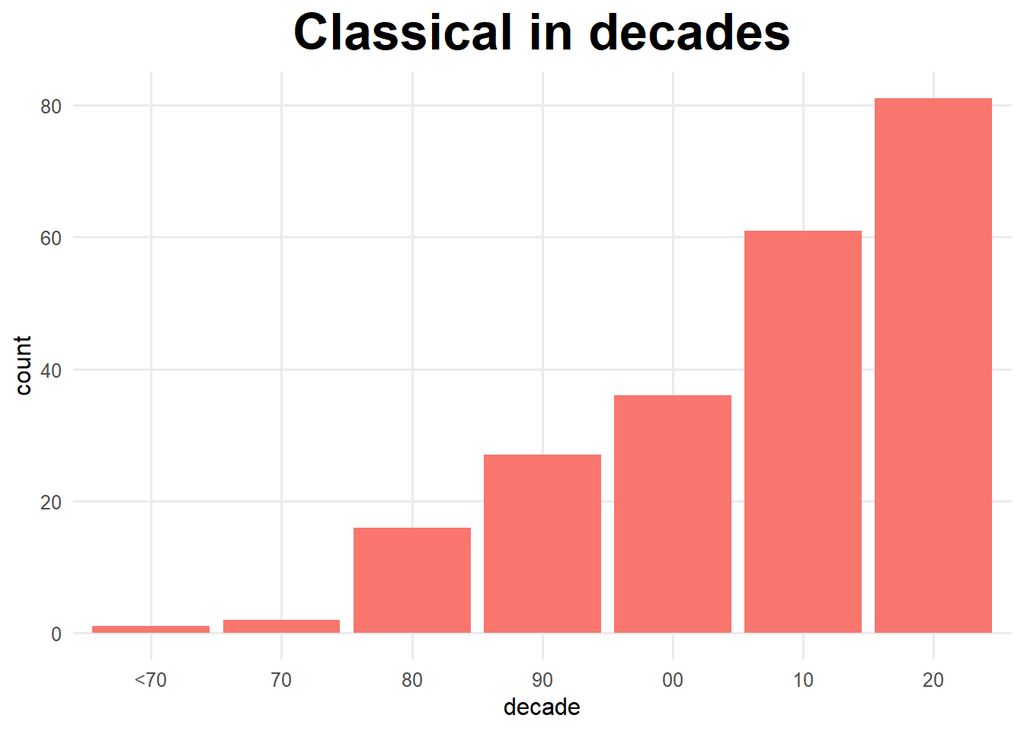

**Country**

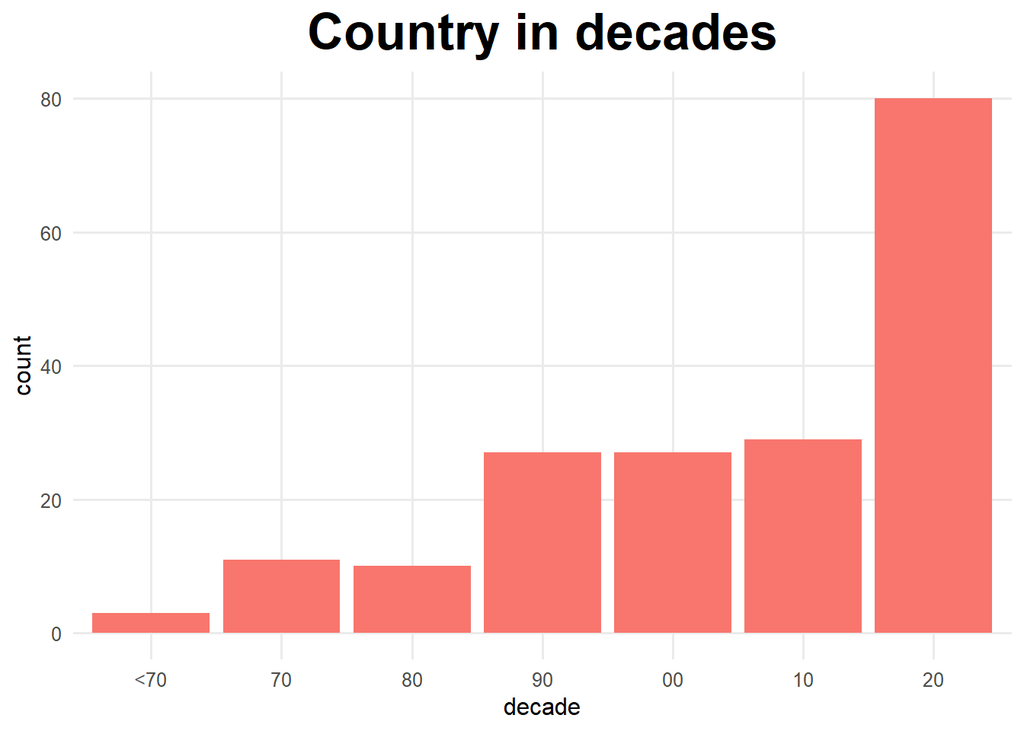

**Folk**

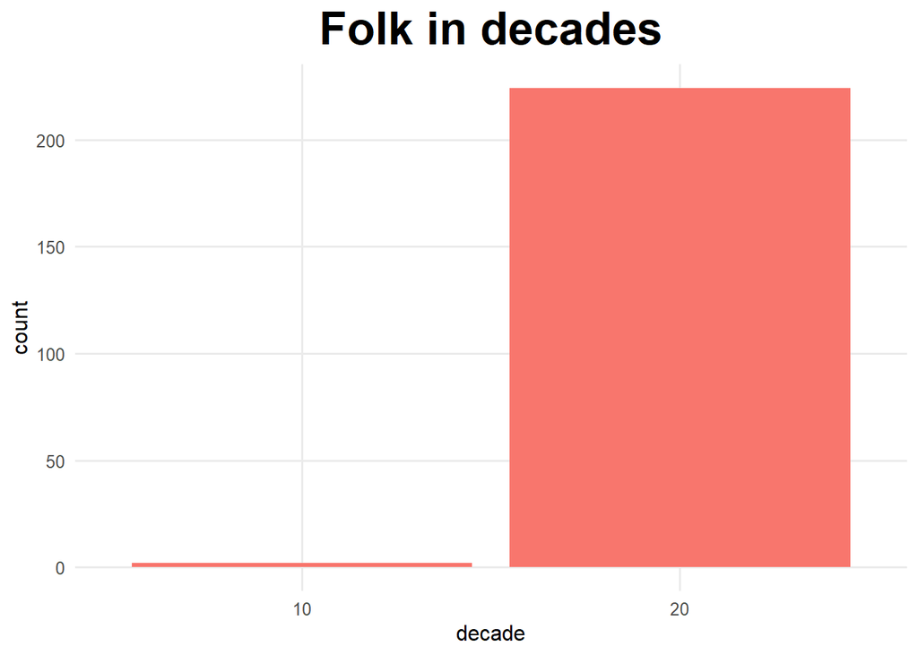

**Jazz**

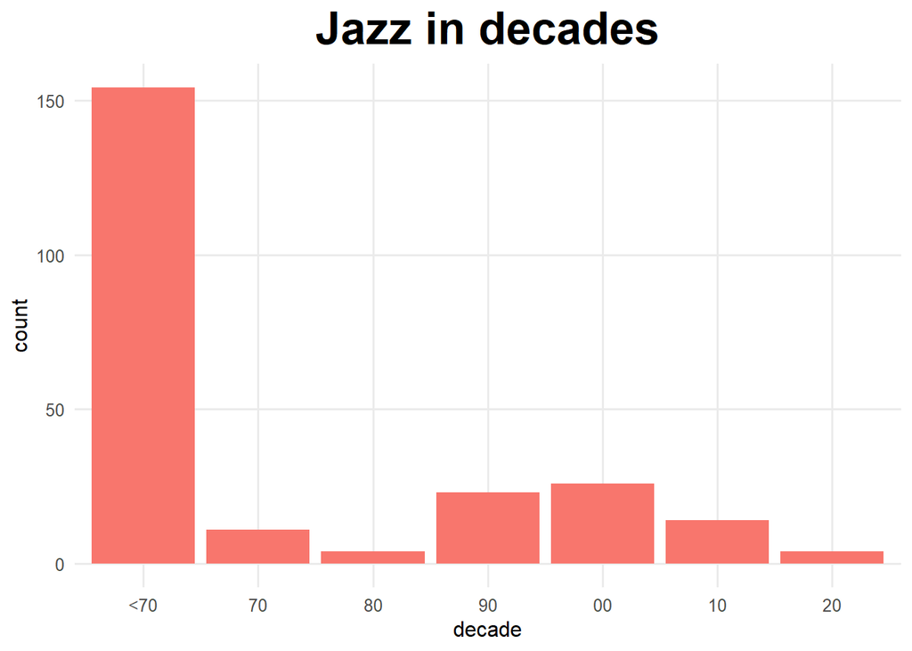

**Hiphop**

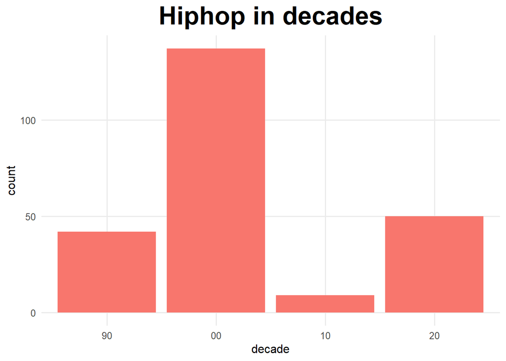

**Reggae**

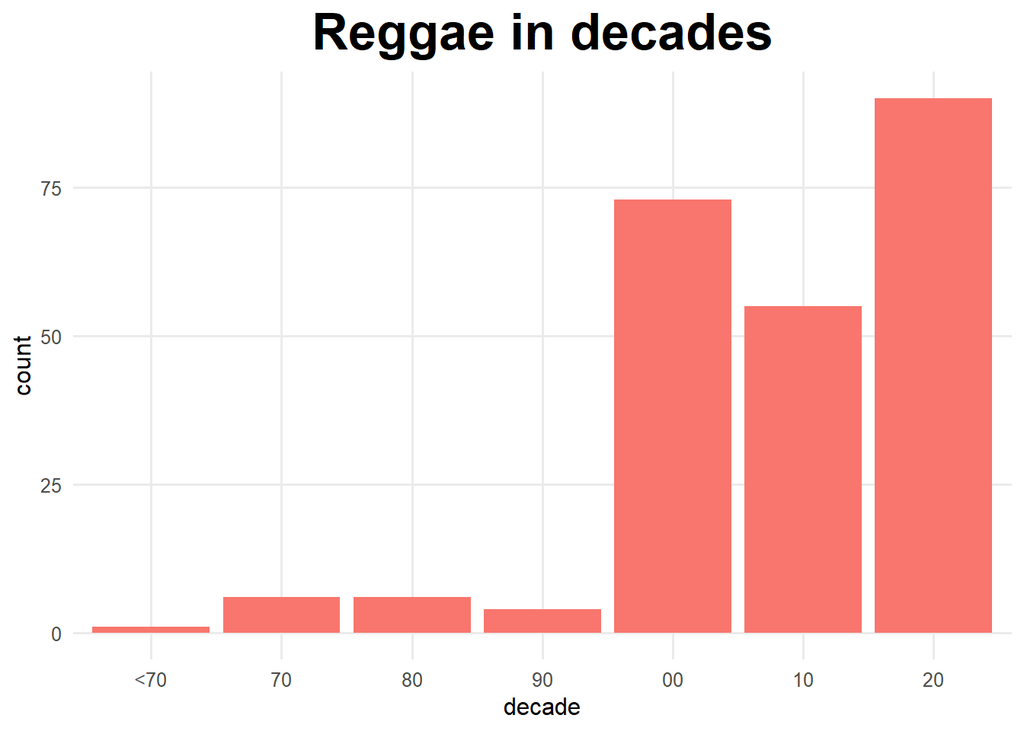

**Rock**

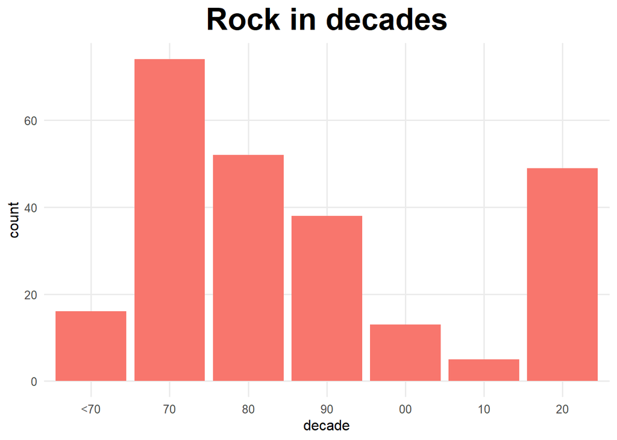

**Metal**

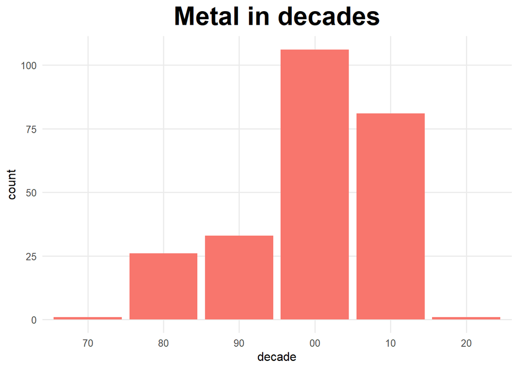

## Explicit Content Depending on Genre

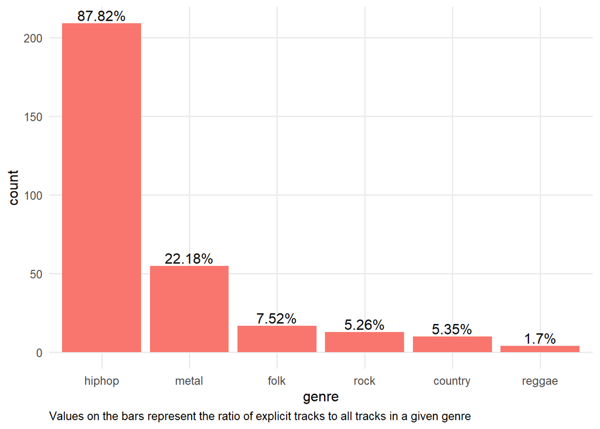

It is no surprise that the most tracks containing explicit content come from the hip-hop genre (almost 90% of tracks from this genre contain them). Next in line is metal, over 1/5 of the tracks from this genre contain content inappropriate for young audiences. The only genres in which there are no profanities are blues, classical music, and jazz.

## Energy vs. Loudness of Tracks

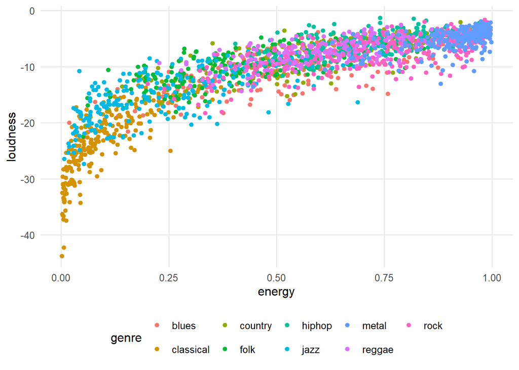

Track energy and loudness are features that seemingly appear to be related. The chart above proves that such a relationship indeed exists: the more energetic the track, the louder it is. Additionally, one can notice that some genres form “clouds”—metal tracks, for example, are tightly clustered in the upper right corner of the chart, meaning they are simultaneously the loudest and most energetic.

## Danceability vs. Positivity of Tracks

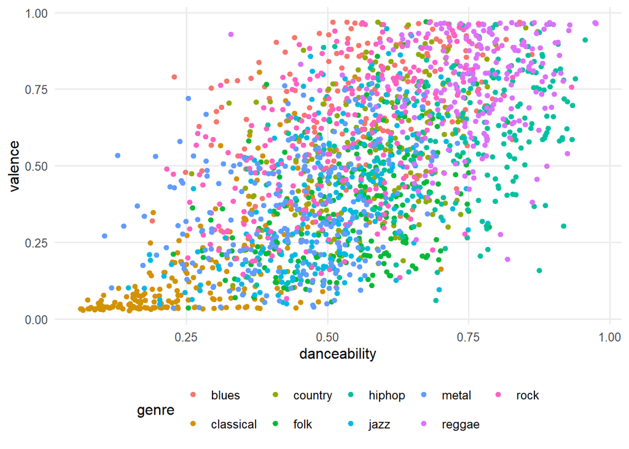

Does a more positive track mean it’s also more suitable for dancing? The chart above shows there is some truth to this. One can notice that the most danceable and positive genre is reggae. It may be surprising, however, that it looks like many classical pieces from the dataset are not suitable for dancing and are exceptionally depressing.

## Loudness of Tracks Over the Years

[interactive chart not shown]

An interesting fact is that in most genres, tracks became louder from decade to decade. It is not a surprise that metal was almost always the loudest genre; in the 20s, it was characterized by an average loudness of -3.23 dB, which starkly contrasts with -23.68 dB for classical music from the same decade.

## Distributions of Track Duration

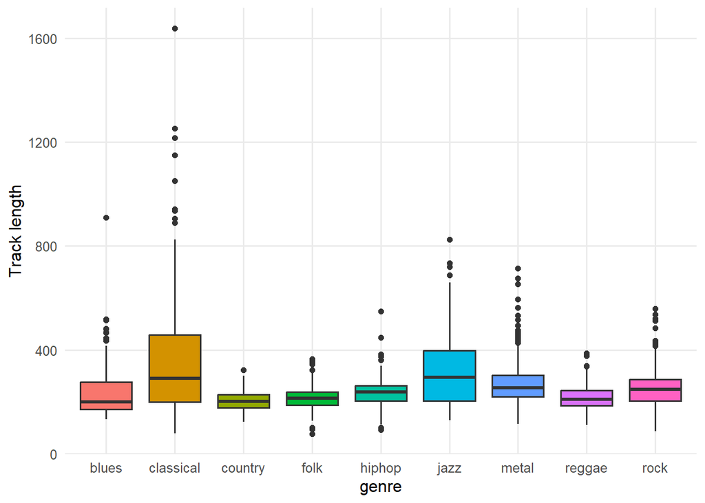

Looking at the box plots of song lengths depending on the genre, one can suspect that there is a chance some distributions are similar to each other. To verify this, I intend to perform an ANOVA test. First, however, I check the required assumptions of multivariate normality in groups, group balancing, and their homogeneity.

| genre | sample_size | p_value |
| --- | --- | --- |
| blues | 181 | 0.0000000 |
| classical | 224 | 0.0000000 |
| country | 187 | 0.0020730 |
| folk | 226 | 0.0095814 |
| hiphop | 238 | 0.0000016 |
| jazz | 236 | 0.0000000 |
| metal | 248 | 0.0000000 |
| reggae | 235 | 0.0000597 |
| rock | 247 | 0.0000000 |

**Display code**

```r
bartlett.test(df$track.duration_s, df$genre)
```

```
    Bartlett test of homogeneity of variances

data:  df$track.duration_s and df$genre
Bartlett's K-squared = 1323, df = 8, p-value < 2.2e-16
```

It looks like none of the assumptions are met, so I will perform the Kruskal-Wallis test, which is the non-parametric equivalent of the ANOVA test.

**Display code**

```r
kruskal.test(track.duration_s ~ genre, df)
```

```
    Kruskal-Wallis rank sum test

data:  track.duration_s by genre
Kruskal-Wallis chi-squared = 278.84, df = 8, p-value < 2.2e-16
```

This test showed that the hypothesis stating that the mean song lengths in genres are at the same level should be rejected. To see which ones differ from each other, I will perform Dunn’s test.

**Display code**

```r
dunntest <- dunn_test(df, track.duration_s ~ genre, p.adjust.method = "bonferroni")
```

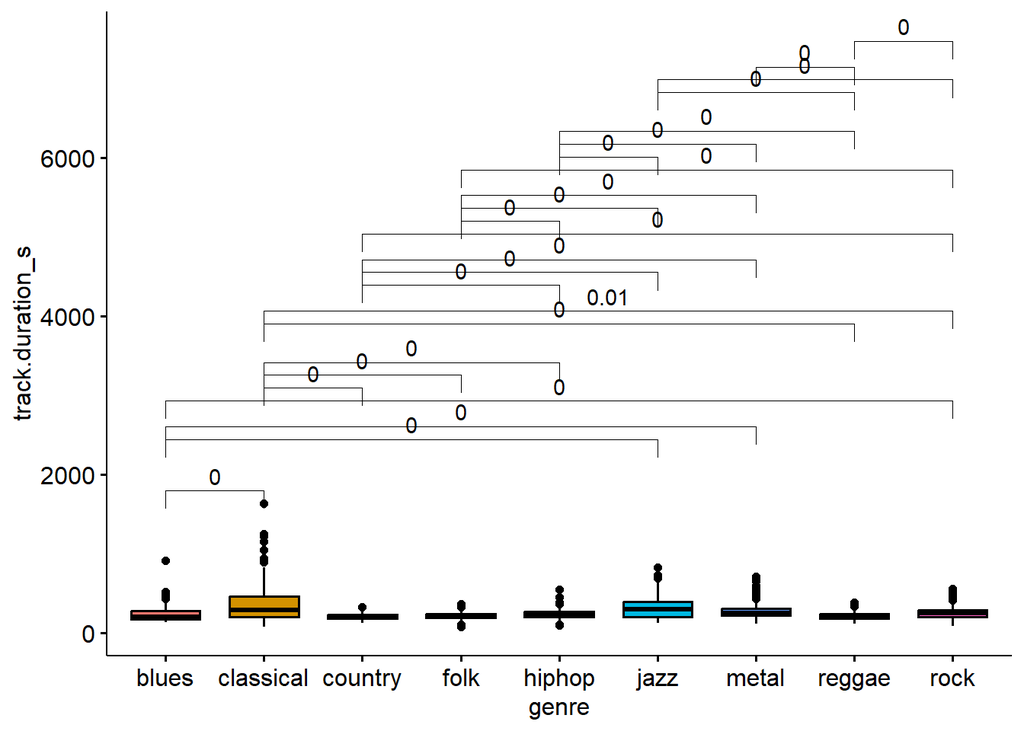

## Dependence of the `valence` Variable on Key

In practice, minor scales and pieces based on them are considered to have a sad sound, as opposed to major scales, which are considered happy.

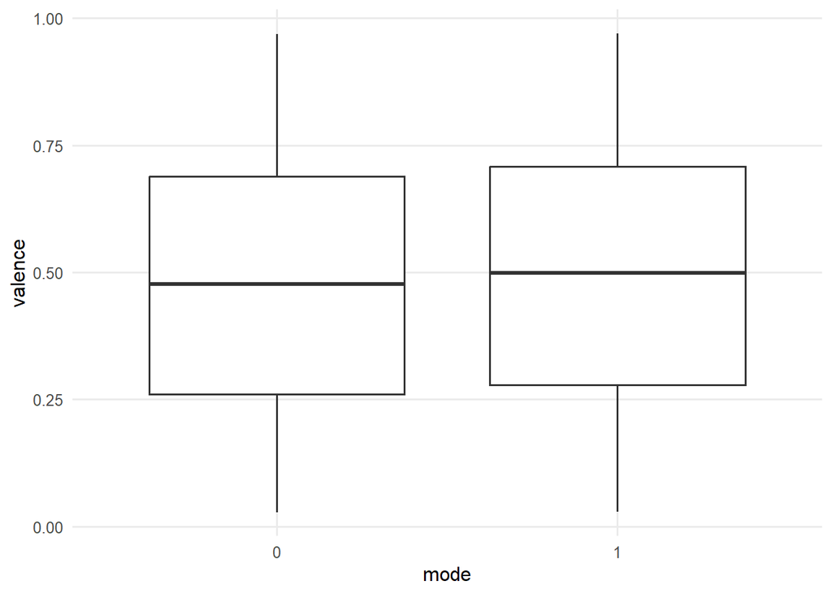

**Display code**

```r
var.test(df[df$mode == 0, ]$valence, df[df$mode == 1, ]$valence)
```

```
    F test to compare two variances

data:  df[df$mode == 0, ]$valence and df[df$mode == 1, ]$valence
F = 1.0126, num df = 661, denom df = 1359, p-value = 0.8461
alternative hypothesis: true ratio of variances is not equal to 1
95 percent confidence interval:
 0.8891214 1.1566664
sample estimates:
ratio of variances
          1.012574
```

The assumption of variance homogeneity is met. I will therefore perform the t-test.

**Display code**

```r
t.test(valence ~ mode, data = df)
```

```
    Welch Two Sample t-test

data:  valence by mode
t = -1.4898, df = 1302.8, p-value = 0.1365
alternative hypothesis: true difference in means between group 0 and group 1 is not equal to 0
95 percent confidence interval:
 -0.042885818  0.005864111
sample estimates:
mean in group 0 mean in group 1
      0.4748066       0.4933175
```

The p-value of the performed test indicates that there is no basis for rejecting the hypothesis of equal means in these distributions. This means that in our dataset, the feature referring to the track’s mood does not depend on the scale, which is a fairly interesting conclusion.